# 02 Excel for Data Science - 2

Designed for Rachel

Harry Lu, dl947@cornell.edu

Jun/03/2022

HOME

# 1 Basics of MS Excel (continue)

## 1.1 Knowing the UI

## 1.2 Tool Area

## 1.3 Functions (continue)

### 1.3.1 Important Concept

- Relative reference v.s. absolute reference

### 1.3.2 Simple Math

- No need to use formulas, just use the operators on the keyboard
- `+`, `-`, `*`, `/`
- `^` (power)

### 1.3.3 Statistics

- `SUM()`
- `AVERAGE()`
- `MIN()`
- `MAX()`
- `MEDIAN()`
- `COUNT()`

### 1.3.4 String

- Concatenation:
  - `<Cell> & <Cell>`
  - `<Cell> & "<string>" & <Cell>`
- E.g.
  - `A1 & B1`
  - `A1 & "-" & B1`

# 2 Fundamental of Table Joining

- Compare with the set operation: intersect and union

## 2.1 Main Types

- Inner join (= join)

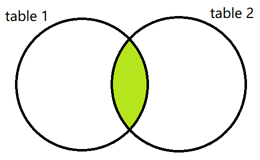

- Left join (= left outer join)

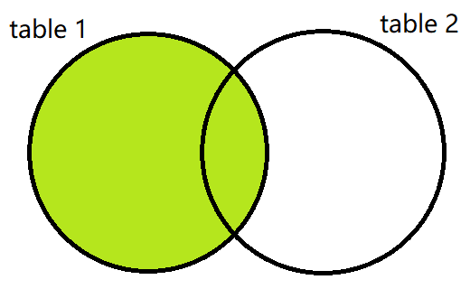

- Right join (= right outer join)

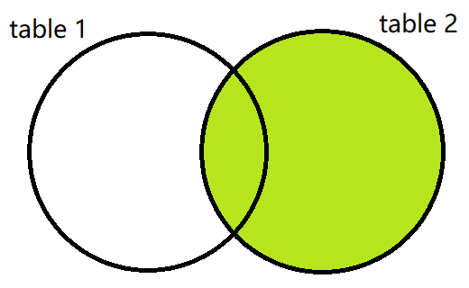

- Full join (= full outer join)

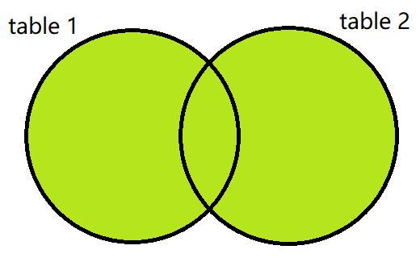

- Left anti join

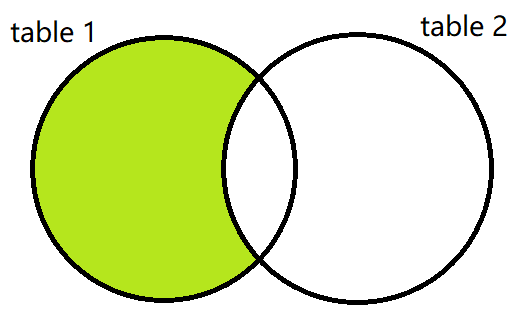

- Right anti join

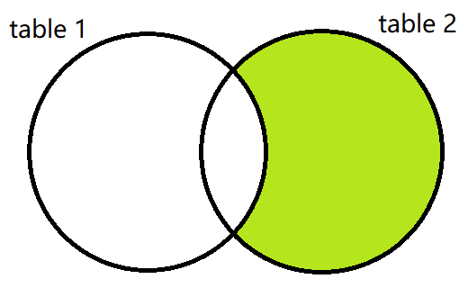

- Cross join
- Self join

## 2.2 Key

- Primary key, from relational database
- Key, from non-relational database

## 2.3 In MS Excel

- Normally, we perform a left join using the tool `VLOOKUP`
- The left table would be the base table
- The right table has a common column of the base table, and it would be used as joining key
- The right table has some additional data that you want to have them on the base table

# 3 Professional Skills of MS Excel

## 3.1 Filter

- Location: “Data” tab
- Functionalities:
  - Sorting
  - Filtering
- These two concepts (sorting and filtering) are very important, and they would be two of the fundamental skills of table / dataframe manipulation

## 3.2 PivotTable

- Location: “Insert” tab
- Functionality:
  - Aggregation
- This concept (aggregation) is very important, and it would be widely used in EDA and reporting

## 3.3 Vlookup

- Location: “Formulas” tab, “Lookup & Reference” section
- Functionality:
  - Table joining (especially left join)
- This concept (joining) is very important, and it would be widely used in extracting the right data from data sources, such as database or multiple tables in memory

**Copyright © 2022 Harry Lu. All rights reserved.**